```python
import numpy as np # linear algebra
import pandas as pd # data processing, CSV file I/O (e.g. pd.read_csv)
import matplotlib.pyplot as plt
import matplotlib
import seaborn as sns

import warnings
warnings.filterwarnings(action="ignore")
%matplotlib inline
warnings.filterwarnings("ignore")
matplotlib.rcParams['font.sans-serif'] = ['SimHei']
matplotlib.rcParams['axes.unicode_minus'] = False
```

```python
data = pd.read_csv("D:/new_data/telco-customer-churn/WA_Fn-UseC_-Telco-Customer-Churn.csv")
```

```python
len(data)
```

```
7043
```

- 一共7043条数据

```python
len(data.columns)
```

```
21
```

- 一共21个特征

```python
data.columns
```

```
Index(['customerID', 'gender', 'SeniorCitizen', 'Partner', 'Dependents',
       'tenure', 'PhoneService', 'MultipleLines', 'InternetService',
       'OnlineSecurity', 'OnlineBackup', 'DeviceProtection', 'TechSupport',
       'StreamingTV', 'StreamingMovies', 'Contract', 'PaperlessBilling',
       'PaymentMethod', 'MonthlyCharges', 'TotalCharges', 'Churn'],
      dtype='object')
```

含义：

- customerID:客户ID
- gender：性别
- SeniorCitizen：老年人（1是，0不是）
- Partner：合作伙伴（Yes、No）
- Dependents：家属
- tenure：任期
- PhoneService：电话服务
- MultipleLines：多线？
- InternetService：互联网服务
- OnlineSecurity：在线安全
- OnlineBackup：在线备份
- DeviceProtection：设备保护
- TechSupport：技术支持
- StreamingTV：流媒体电视
- StreamingMovies：流媒体电影
- Contract：合约方式
- PaperlessBilling：无纸账单
- PaymentMethod：付款方式
- MonthlyCharges：每月费用
- TotalCharges：总费用
- Churn：用户流失

上面是每个特征的含义，方便理解

```python
data.isnull().sum()
```

```
customerID          0
gender              0
SeniorCitizen       0
Partner             0
Dependents          0
tenure              0
PhoneService        0
MultipleLines       0
InternetService     0
OnlineSecurity      0
OnlineBackup        0
DeviceProtection    0
TechSupport         0
StreamingTV         0
StreamingMovies     0
Contract            0
PaperlessBilling    0
PaymentMethod       0
MonthlyCharges      0
TotalCharges        0
Churn               0
dtype: int64
```

- 数据中不存在缺失的情况

下面要对数据做一些基本的处理

```python
#转换数据类型
data['TotalCharges'] = data["TotalCharges"].replace(" ",0)
data['TotalCharges'] = data['TotalCharges'].astype(float)
```

有些特征中的取值存在一定的重复，需要进行统一的处理

```python
cols = [ 'OnlineSecurity', 'OnlineBackup', 'DeviceProtection',
                'TechSupport','StreamingTV', 'StreamingMovies']

for col in cols:
    data[col] = data[col].replace({"No internet service":'No'})
```

下面对特征值进行适当的转换

```python
data['SeniorCitizen'] = data['SeniorCitizen'].replace({1:'Yes',0:'No'})
```

```python
#转换tenure
def tenure(data):
    if data <= 12:
        return 't_0_12'
    elif (data > 12) & (data <= 24):
        return 't_12_24'
    elif (data > 24) & (data <= 48):
        return 't_24_48'
    elif (data > 48) & (data <= 60):
        return 't_48_60'
    else:
        return 't_60'
```

```python
data["tenure_group"] = data['tenure'].apply(tenure)
```

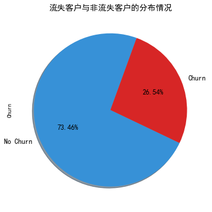

```python
f,ax = plt.subplots(1,1,figsize=(14,6))
colors = ["#3791D7","#D72626"]
labels = ["No Churn","Churn"]

data["Churn"].value_counts().plot.pie(autopct='%1.2f%%',ax=ax,shadow=True,
                                      colors=colors,labels=labels, fontsize=12, startangle=70)
ax.set_title('流失客户与非流失客户的分布情况', fontsize=14)
```

- 结果显示有27%的客户已经流失了，73%的客户还在使用我们的服务

下面观察不同特征维度与是否流失之间的关系

性别

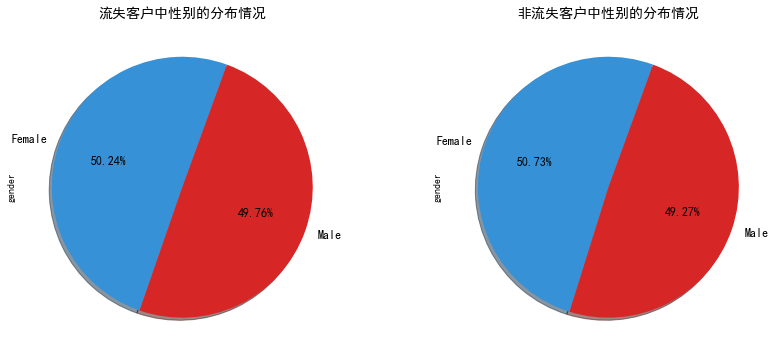

```python
f,ax = plt.subplots(1,2,figsize=(14,6))
colors = ["#3791D7","#D72626"]
labels = ["Female","Male"]

data[data.Churn == 'Yes']["gender"].value_counts().plot.pie(autopct='%1.2f%%',ax=ax[0],shadow=True,
                                      colors=colors,labels=labels, fontsize=12, startangle=70)
ax[0].set_title('流失客户中性别的分布情况', fontsize=14)

data[data.Churn == 'No']["gender"].value_counts().plot.pie(autopct='%1.2f%%',ax=ax[1],shadow=True,
                                      colors=colors,labels=labels,fontsize=12, startangle=70)
ax[1].set_title('非流失客户中性别的分布情况', fontsize=14)
```

- 从上面的结果可以看出，在不同性别的数据中，流失与非流失的比例是基本一致的，所以性别对于是否流失是没有影响的

观察是否是老年人与客户流失之间的关系

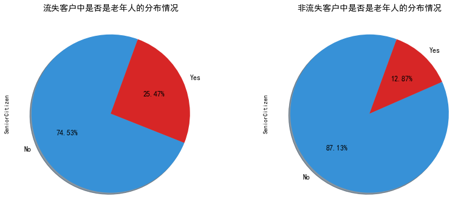

```python
f,ax = plt.subplots(1,2,figsize=(14,6))
colors = ["#3791D7","#D72626"]
labels = ["No","Yes"]

data[data.Churn == 'Yes']["SeniorCitizen"].value_counts().plot.pie(autopct='%1.2f%%',ax=ax[0],shadow=True,
                                      colors=colors,labels=labels, fontsize=12, startangle=70)
ax[0].set_title('流失客户中是否是老年人的分布情况', fontsize=14)

data[data.Churn == 'No']["SeniorCitizen"].value_counts().plot.pie(autopct='%1.2f%%',ax=ax[1],shadow=True,
                                      colors=colors,labels=labels,fontsize=12, startangle=70)
ax[1].set_title('非流失客户中是否是老年人的分布情况', fontsize=14)
```

观察是否是合伙人与流失之间的关系

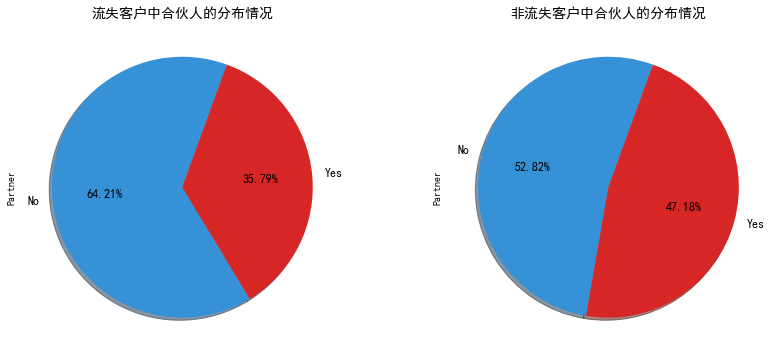

```python
f,ax = plt.subplots(1,2,figsize=(14,6))
colors = ["#3791D7","#D72626"]
labels = ["No","Yes"]

data[data.Churn == 'Yes']["Partner"].value_counts().plot.pie(autopct='%1.2f%%',ax=ax[0],shadow=True,
                                      colors=colors,labels=labels, fontsize=12, startangle=70)
ax[0].set_title('流失客户中合伙人的分布情况', fontsize=14)

data[data.Churn == 'No']["Partner"].value_counts().plot.pie(autopct='%1.2f%%',ax=ax[1],shadow=True,
                                      colors=colors,labels=labels,fontsize=12, startangle=70)
ax[1].set_title('非流失客户中合伙人的分布情况', fontsize=14)
```

观察家属与是否流失之间的关系

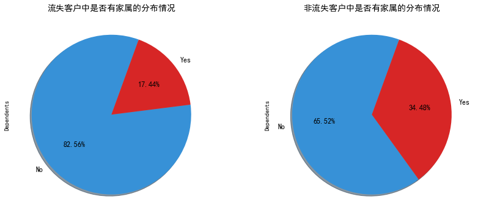

```python
f,ax = plt.subplots(1,2,figsize=(14,6))
colors = ["#3791D7","#D72626"]
labels = ["No","Yes"]

data[data.Churn == 'Yes']["Dependents"].value_counts().plot.pie(autopct='%1.2f%%',ax=ax[0],shadow=True,
                                      colors=colors,labels=labels, fontsize=12, startangle=70)
ax[0].set_title('流失客户中是否有家属的分布情况', fontsize=14)

data[data.Churn == 'No']["Dependents"].value_counts().plot.pie(autopct='%1.2f%%',ax=ax[1],shadow=True,
                                      colors=colors,labels=labels,fontsize=12, startangle=70)
ax[1].set_title('非流失客户中是否有家属的分布情况', fontsize=14)
```

- 家属客户群的流失比例为17%，而非家属客户群中的流失比例为34%
- 结论：如果是非家属，则客户流失的要更严重

观察电话服务与是否流失之间的关系

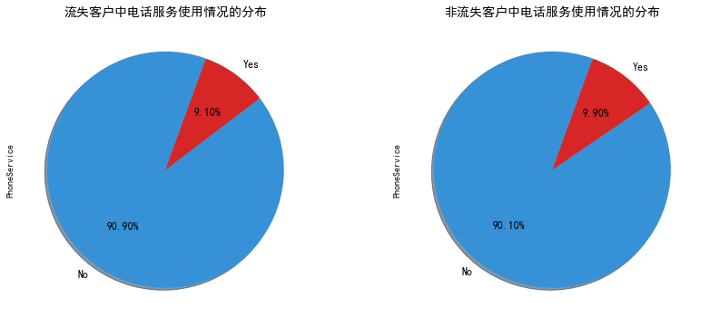

```python
f,ax = plt.subplots(1,2,figsize=(14,6))
colors = ["#3791D7","#D72626"]
labels = ["No","Yes"]

data[data.Churn == 'Yes']["PhoneService"].value_counts().plot.pie(autopct='%1.2f%%',ax=ax[0],shadow=True,
                                      colors=colors,labels=labels, fontsize=12, startangle=70)
ax[0].set_title('流失客户中电话服务使用情况的分布', fontsize=14)

data[data.Churn == 'No']["PhoneService"].value_counts().plot.pie(autopct='%1.2f%%',ax=ax[1],shadow=True,
                                      colors=colors,labels=labels,fontsize=12, startangle=70)
ax[1].set_title('非流失客户中电话服务使用情况的分布', fontsize=14)
```

- 差异不明显，所以这个特征对是否流失并没有影响

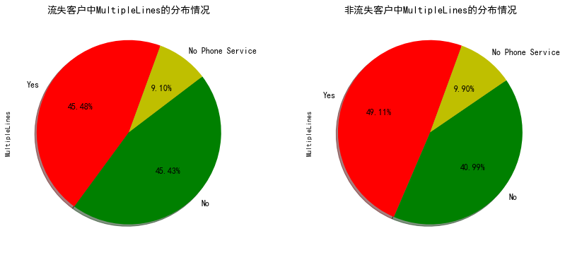

```python
f,ax = plt.subplots(1,2,figsize=(14,6))
colors = ["r","g",'y']
labels = ["Yes","No","No Phone Service"]

data[data.Churn == 'Yes']["MultipleLines"].value_counts().plot.pie(autopct='%1.2f%%',ax=ax[0],shadow=True,
                                      colors=colors,labels=labels, fontsize=12, startangle=70)
ax[0].set_title('流失客户中MultipleLines的分布情况', fontsize=14)

data[data.Churn == 'No']["MultipleLines"].value_counts().plot.pie(autopct='%1.2f%%',ax=ax[1],shadow=True,
                                      colors=colors,labels=labels,fontsize=12, startangle=70)
ax[1].set_title('非流失客户中MultipleLines的分布情况', fontsize=14)
```

- 差异不明显，所以这个特征对是否流失是没有影响的

观察使用不同因特网服务的客户群中流失情况

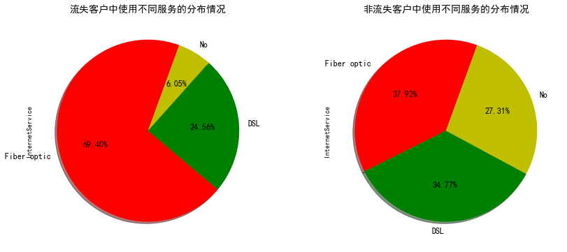

```python
f,ax = plt.subplots(1,2,figsize=(14,6))
colors = ["r","g",'y']
labels = ["Fiber optic","DSL","No"]

data[data.Churn == 'Yes']["InternetService"].value_counts().plot.pie(autopct='%1.2f%%',ax=ax[0],shadow=True,
                                      colors=colors,labels=labels, fontsize=12, startangle=70)
ax[0].set_title('流失客户中使用不同服务的分布情况', fontsize=14)

data[data.Churn == 'No']["InternetService"].value_counts().plot.pie(autopct='%1.2f%%',ax=ax[1],shadow=True,
                                      colors=colors,labels=labels,fontsize=12, startangle=70)
ax[1].set_title('非流失客户中使用不同服务的分布情况', fontsize=14)
```

- 在流失的客户群中，使用Fiber optic的比例非常高，占了69%；而未流失的客户群中，三者的比例是比较均匀的
- 结论：从流失数据中可以看出使用Fiber optic服务后会更容易流失，所以需要针对这种类型的服务进行改进

下面都是为客户提供的一些附加服务，或者是售后服务

下面观察在线安全对是否流失的影响

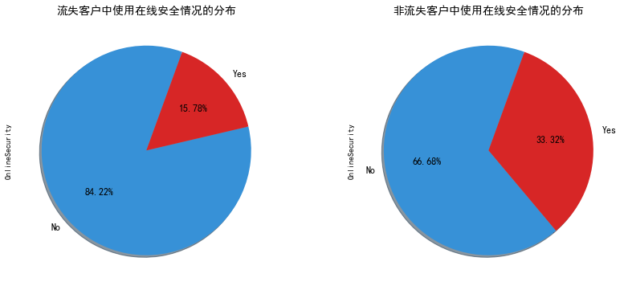

```python
f,ax = plt.subplots(1,2,figsize=(14,6))
colors = ["#3791D7","#D72626"]
labels = ["No","Yes"]

data[data.Churn == 'Yes']["OnlineSecurity"].value_counts().plot.pie(autopct='%1.2f%%',ax=ax[0],shadow=True,
                                      colors=colors,labels=labels, fontsize=12, startangle=70)
ax[0].set_title('流失客户中使用在线安全情况的分布', fontsize=14)

data[data.Churn == 'No']["OnlineSecurity"].value_counts().plot.pie(autopct='%1.2f%%',ax=ax[1],shadow=True,
                                      colors=colors,labels=labels,fontsize=12, startangle=70)
ax[1].set_title('非流失客户中使用在线安全情况的分布', fontsize=14)
```

- 在流失客户群中在线安全使用率比较低，只占了16%；而非流失客户群众的占比是33%
- 结论：拥有在线安全服务的客户更不容易流失

下面观察在线备份功能对客户流失的影响

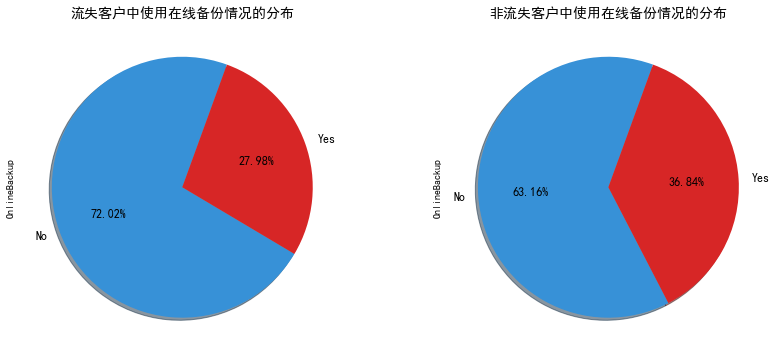

```python
f,ax = plt.subplots(1,2,figsize=(14,6))
colors = ["#3791D7","#D72626"]
labels = ["No","Yes"]

data[data.Churn == 'Yes']["OnlineBackup"].value_counts().plot.pie(autopct='%1.2f%%',ax=ax[0],shadow=True,
                                      colors=colors,labels=labels, fontsize=12, startangle=70)
ax[0].set_title('流失客户中使用在线备份情况的分布', fontsize=14)

data[data.Churn == 'No']["OnlineBackup"].value_counts().plot.pie(autopct='%1.2f%%',ax=ax[1],shadow=True,
                                      colors=colors,labels=labels,fontsize=12, startangle=70)
ax[1].set_title('非流失客户中使用在线备份情况的分布', fontsize=14)
```

- 结论：拥有在线备份服务的客户更不容易流失

观察设备保护对于客户流失的影响

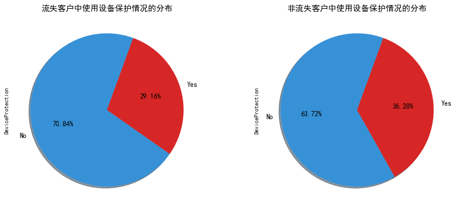

```python
f,ax = plt.subplots(1,2,figsize=(14,6))
colors = ["#3791D7","#D72626"]
labels = ["No","Yes"]

data[data.Churn == 'Yes']["DeviceProtection"].value_counts().plot.pie(autopct='%1.2f%%',ax=ax[0],shadow=True,
                                      colors=colors,labels=labels, fontsize=12, startangle=70)
ax[0].set_title('流失客户中使用设备保护情况的分布', fontsize=14)

data[data.Churn == 'No']["DeviceProtection"].value_counts().plot.pie(autopct='%1.2f%%',ax=ax[1],shadow=True,
                                      colors=colors,labels=labels,fontsize=12, startangle=70)
ax[1].set_title('非流失客户中使用设备保护情况的分布', fontsize=14)
```

- 结论：拥有设备保护服务的客户更不容易流失

下面观察技术支持对客户流失的影响

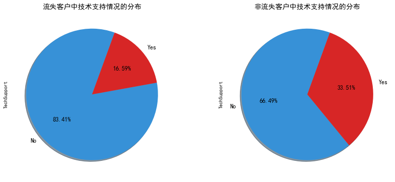

```python
f,ax = plt.subplots(1,2,figsize=(14,6))
colors = ["#3791D7","#D72626"]
labels = ["No","Yes"]

data[data.Churn == 'Yes']["TechSupport"].value_counts().plot.pie(autopct='%1.2f%%',ax=ax[0],shadow=True,
                                      colors=colors,labels=labels, fontsize=12, startangle=70)
ax[0].set_title('流失客户中技术支持情况的分布', fontsize=14)

data[data.Churn == 'No']["TechSupport"].value_counts().plot.pie(autopct='%1.2f%%',ax=ax[1],shadow=True,
                                      colors=colors,labels=labels,fontsize=12, startangle=70)
ax[1].set_title('非流失客户中技术支持情况的分布', fontsize=14)
```

- 在流失的客户群中使用技术支持的人很少，只占了17%，而非流失的客户群众占了34%
- 结论：拥有技术支持服务的客户更不容易流失

观察流媒体电视对客户流失的影响

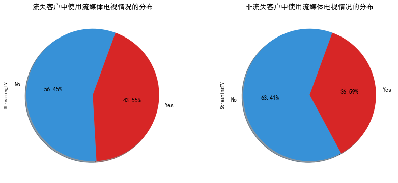

```python
f,ax = plt.subplots(1,2,figsize=(14,6))
colors = ["#3791D7","#D72626"]
labels = ["No","Yes"]

data[data.Churn == 'Yes']["StreamingTV"].value_counts().plot.pie(autopct='%1.2f%%',ax=ax[0],shadow=True,
                                      colors=colors,labels=labels, fontsize=12, startangle=70)
ax[0].set_title('流失客户中使用流媒体电视情况的分布', fontsize=14)

data[data.Churn == 'No']["StreamingTV"].value_counts().plot.pie(autopct='%1.2f%%',ax=ax[1],shadow=True,
                                      colors=colors,labels=labels,fontsize=12, startangle=70)
ax[1].set_title('非流失客户中使用流媒体电视情况的分布', fontsize=14)
```

- 差异并不明显，说明是否使用流媒体电视对于客户的流失没有多大的影响

下面观察流媒体电影对客户流失的影响

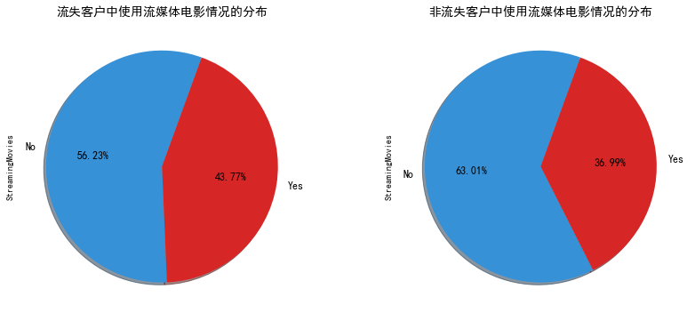

```python
f,ax = plt.subplots(1,2,figsize=(14,6))
colors = ["#3791D7","#D72626"]
labels = ["No","Yes"]

data[data.Churn == 'Yes']["StreamingMovies"].value_counts().plot.pie(autopct='%1.2f%%',ax=ax[0],shadow=True,
                                      colors=colors,labels=labels, fontsize=12, startangle=70)
ax[0].set_title('流失客户中使用流媒体电影情况的分布', fontsize=14)

data[data.Churn == 'No']["StreamingMovies"].value_counts().plot.pie(autopct='%1.2f%%',ax=ax[1],shadow=True,
                                      colors=colors,labels=labels,fontsize=12, startangle=70)
ax[1].set_title('非流失客户中使用流媒体电影情况的分布', fontsize=14)
```

差异不明显，说明是否使用流媒体电影对于客户的流失没有多大的影响

下面观察合约方式对于客户流失的影响

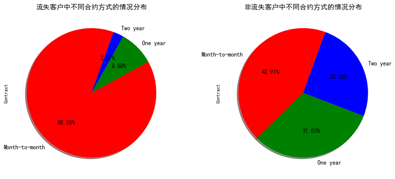

```python
f,ax = plt.subplots(1,2,figsize=(14,6))
colors = ["r","g","b"]
labels = ["Month-to-month","One year","Two year"]

data[data.Churn == 'Yes']["Contract"].value_counts().plot.pie(autopct='%1.2f%%',ax=ax[0],shadow=True,
                                      colors=colors,labels=labels, fontsize=12, startangle=70)
ax[0].set_title('流失客户中不同合约方式的情况分布', fontsize=14)

data[data.Churn == 'No']["Contract"].value_counts().plot.pie(autopct='%1.2f%%',ax=ax[1],shadow=True,
                                      colors=colors,labels=labels,fontsize=12, startangle=70)
ax[1].set_title('非流失客户中不同合约方式的情况分布', fontsize=14)
```

- 流失客户群众多数都在用按月的方式，占了89%；而非流失的客户群众，One year和Two year的方式要更多
- 结论：短期合约的客户流失较高

下面观察无纸账单对客户流失的影响

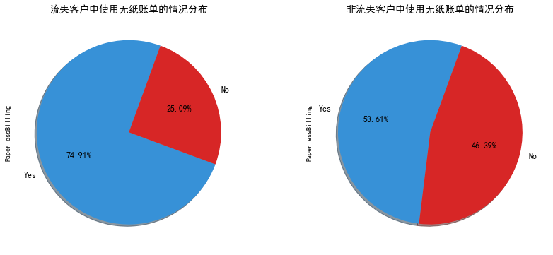

```python
f,ax = plt.subplots(1,2,figsize=(14,6))
colors = ["#3791D7","#D72626"]
labels = ["Yes","No"]

data[data.Churn == 'Yes']["PaperlessBilling"].value_counts().plot.pie(autopct='%1.2f%%',ax=ax[0],shadow=True,
                                      colors=colors,labels=labels, fontsize=12, startangle=70)
ax[0].set_title('流失客户中使用无纸账单的情况分布', fontsize=14)

data[data.Churn == 'No']["PaperlessBilling"].value_counts().plot.pie(autopct='%1.2f%%',ax=ax[1],shadow=True,
                                      colors=colors,labels=labels,fontsize=12, startangle=70)
ax[1].set_title('非流失客户中使用无纸账单的情况分布', fontsize=14)
```

- 在流失的客户群体中使用无纸账单的占比为75%，而非流失客户群中的占比未54%
- 结论：对于这样服务方式还需要进行改进

下面观察支付方式对客户流失的影响

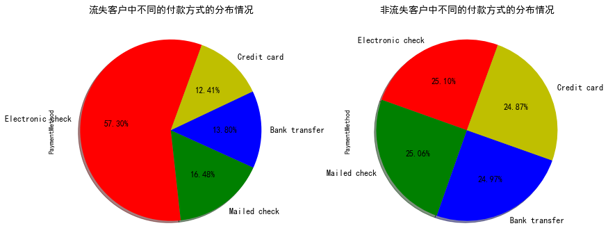

```python
f,ax = plt.subplots(1,2,figsize=(14,6))
colors = ["r","g","b","y"]
labels = ["Electronic check","Mailed check","Bank transfer","Credit card"]

data[data.Churn == 'Yes']["PaymentMethod"].value_counts().plot.pie(autopct='%1.2f%%',ax=ax[0],shadow=True,
                                      colors=colors,labels=labels, fontsize=12, startangle=70)
ax[0].set_title('流失客户中不同的付款方式的分布情况', fontsize=14)

data[data.Churn == 'No']["PaymentMethod"].value_counts().plot.pie(autopct='%1.2f%%',ax=ax[1],shadow=True,
                                      colors=colors,labels=labels,fontsize=12, startangle=70)
ax[1].set_title('非流失客户中不同的付款方式的分布情况', fontsize=14)
```

- 在流失客户群中使用电子发票的方式的人比较多，占了57%，而其他的就偏少；而在非流失的客户群众，各种方式的分布情况是比较均匀的
- 结论：受到了电子发票这种方式的影响

下面观察使用期限的分组对客户流失的影响

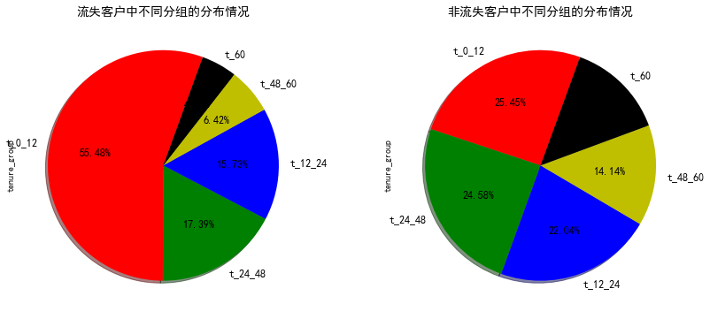

```python
f,ax = plt.subplots(1,2,figsize=(14,6))
colors = ["r","g","b","y","black"]
labels = ["t_0_12","t_24_48","t_12_24","t_48_60","t_60"]

data[data.Churn == 'Yes']["tenure_group"].value_counts().plot.pie(autopct='%1.2f%%',ax=ax[0],shadow=True,
                                      colors=colors,labels=labels, fontsize=12, startangle=70)
ax[0].set_title('流失客户中不同分组的分布情况', fontsize=14)

data[data.Churn == 'No']["tenure_group"].value_counts().plot.pie(autopct='%1.2f%%',ax=ax[1],shadow=True,
                                      colors=colors,labels=labels,fontsize=12, startangle=70)
ax[1].set_title('非流失客户中不同分组的分布情况', fontsize=14)
```

- 在流失客户群中，使用期限很少的占比很高，占了55%，这也符合实际规律，因为流失客户的使用时间一般会比较短；而非流失的客户群众，各类别的客户的分布是比较均匀的
- 短期合约的客户流失较高

下面观察tenure与客户流失之间的关系

下面观察tenure、MonthlyChargeds和TotalCharges对客户是否流失的影响

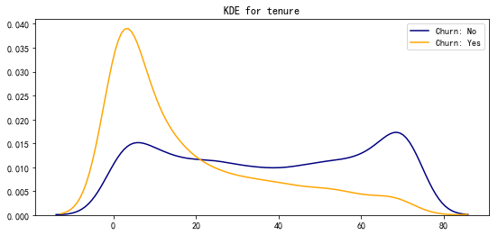

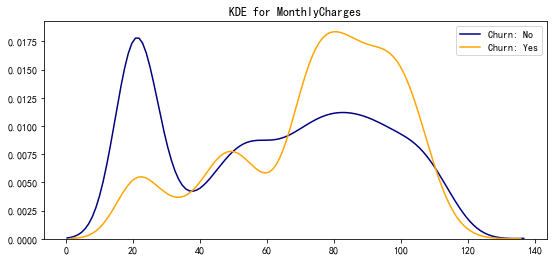

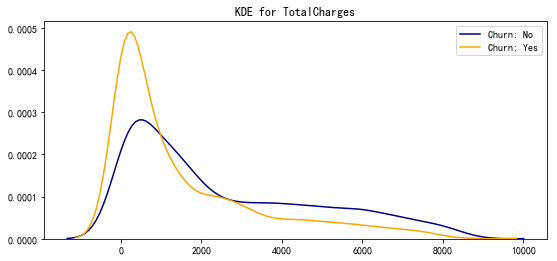

```python
#折线图
def kdeplot(feature):
    plt.figure(figsize=(9,4))
    plt.title("KDE for {}".format(feature))
    ax0 = sns.kdeplot(data[data['Churn'] == 'No'][feature].dropna(), color= 'navy', label= 'Churn: No')
    ax1 = sns.kdeplot(data[data['Churn'] == 'Yes'][feature].dropna(), color= 'orange', label= 'Churn: Yes')

kdeplot('tenure')
kdeplot('MonthlyCharges')
kdeplot('TotalCharges')
```

- 新近的客户更容易流失
- 月费较高的人也更容易流失

下面为了构建模型，需要先将数据进行一些适当的转换

```python
from sklearn.preprocessing import LabelEncoder
from sklearn.preprocessing import StandardScaler
```

```python
Id_col = ['customerID']
target_col = ["Churn"]

#类别特征
cat_cols   = data.nunique()[data.nunique() < 6].keys().tolist()
cat_cols   = [x for x in cat_cols if x not in target_col]

#数值特征
num_cols   = [x for x in data.columns if x not in cat_cols + target_col + Id_col]

#二分值特征
bin_cols   = data.nunique()[data.nunique() == 2].keys().tolist()

#多列值
multi_cols = [i for i in cat_cols if i not in bin_cols]
```

```python
#进行二值处理
le = LabelEncoder()
for col in bin_cols:
    data[col] = le.fit_transform(data[col])

#独热编码
data = pd.get_dummies(data = data,columns = multi_cols)
```

```python
#对数值进行标准化处理
#对数值进行缩放
#减少特征之间量纲的影响
#加快算法的运行效果
ss = StandardScaler()
ss_data = ss.fit_transform(data[num_cols])
ss_data = pd.DataFrame(ss_data,columns=num_cols)

#重组数据
copy_data = data.copy()
data = data.drop(columns = num_cols,axis = 1)
data = data.merge(ss_data,left_index=True,right_index=True,how = "left")
```

```python
#输出特征之间的相关性
#介于-1到1之间，-1是完全负相关，1是完全正相关
data.corr()
```

|  | gender | SeniorCitizen | Partner | Dependents | PhoneService | OnlineSecurity | OnlineBackup | DeviceProtection | TechSupport | StreamingTV | ... | PaymentMethod_Electronic check | PaymentMethod_Mailed check | tenure_group_t_0_12 | tenure_group_t_12_24 | tenure_group_t_24_48 | tenure_group_t_48_60 | tenure_group_t_60 | tenure | MonthlyCharges | TotalCharges |
| --- | --- | --- | --- | --- | --- | --- | --- | --- | --- | --- | --- | --- | --- | --- | --- | --- | --- | --- | --- | --- | --- |
| gender | 1.000000 | -0.001874 | -0.001808 | 0.010517 | -0.006488 | -0.017021 | -0.013773 | -0.002105 | -0.009212 | -0.008393 | ... | 0.000752 | 0.013744 | -0.000858 | -0.000701 | -0.010575 | -0.004362 | 0.016199 | 0.005106 | -0.014569 | -0.000080 |
| SeniorCitizen | -0.001874 | 1.000000 | 0.016479 | -0.211185 | 0.008576 | -0.038653 | 0.066572 | 0.059428 | -0.060625 | 0.105378 | ... | 0.171718 | -0.153477 | -0.028687 | 0.002144 | 0.020748 | 0.014434 | -0.002062 | 0.016567 | 0.220173 | 0.103006 |
| Partner | -0.001808 | 0.016479 | 1.000000 | 0.452676 | 0.017706 | 0.143106 | 0.141498 | 0.153786 | 0.119999 | 0.124666 | ... | -0.083852 | -0.095125 | -0.302718 | -0.048868 | 0.027871 | 0.104860 | 0.279545 | 0.379697 | 0.096848 | 0.317504 |
| Dependents | 0.010517 | -0.211185 | 0.452676 | 1.000000 | -0.001762 | 0.080972 | 0.023671 | 0.013963 | 0.063268 | -0.016558 | ... | -0.150642 | 0.059071 | -0.141295 | -0.002443 | 0.023301 | 0.030483 | 0.116656 | 0.159712 | -0.113890 | 0.062078 |
| PhoneService | -0.006488 | 0.008576 | 0.017706 | -0.001762 | 1.000000 | -0.092893 | -0.052312 | -0.071227 | -0.096340 | -0.022574 | ... | 0.003062 | -0.003319 | -0.007598 | 0.012473 | -0.014511 | -0.009571 | 0.020708 | 0.008448 | 0.247398 | 0.113214 |
| OnlineSecurity | -0.017021 | -0.038653 | 0.143106 | 0.080972 | -0.092893 | 1.000000 | 0.283832 | 0.275438 | 0.354931 | 0.176207 | ... | -0.112338 | -0.080798 | -0.241371 | -0.055714 | 0.007542 | 0.071493 | 0.262805 | 0.327203 | 0.296594 | 0.411651 |
| OnlineBackup | -0.013773 | 0.066572 | 0.141498 | 0.023671 | -0.052312 | 0.283832 | 1.000000 | 0.303546 | 0.294233 | 0.282106 | ... | -0.000408 | -0.174164 | -0.266595 | -0.084028 | 0.023028 | 0.099080 | 0.278479 | 0.360277 | 0.441780 | 0.509226 |
| DeviceProtection | -0.002105 | 0.059428 | 0.153786 | 0.013963 | -0.071227 | 0.275438 | 0.303546 | 1.000000 | 0.333313 | 0.390874 | ... | -0.003351 | -0.187373 | -0.273127 | -0.077286 | 0.044891 | 0.076761 | 0.275230 | 0.360653 | 0.482692 | 0.521983 |
| TechSupport | -0.009212 | -0.060625 | 0.119999 | 0.063268 | -0.096340 | 0.354931 | 0.294233 | 0.333313 | 1.000000 | 0.278070 | ... | -0.114839 | -0.085509 | -0.237622 | -0.072049 | 0.021975 | 0.062554 | 0.264980 | 0.324221 | 0.338304 | 0.431883 |
| StreamingTV | -0.008393 | 0.105378 | 0.124666 | -0.016558 | -0.022574 | 0.176207 | 0.282106 | 0.390874 | 0.278070 | 1.000000 | ... | 0.144626 | -0.247742 | -0.220308 | -0.050161 | 0.028837 | 0.087917 | 0.197993 | 0.279756 | 0.629603 | 0.514973 |
| StreamingMovies | -0.010487 | 0.120176 | 0.117412 | -0.039741 | -0.032959 | 0.187398 | 0.274501 | 0.402111 | 0.279358 | 0.533094 | ... | 0.137966 | -0.250595 | -0.222300 | -0.053907 | 0.025544 | 0.086907 | 0.207863 | 0.286111 | 0.627429 | 0.520122 |
| PaperlessBilling | -0.011754 | 0.156530 | -0.014877 | -0.111377 | 0.016505 | -0.003636 | 0.126735 | 0.103797 | 0.037880 | 0.223841 | ... | 0.208865 | -0.205398 | -0.005365 | 0.003744 | -0.004832 | 0.010987 | -0.000905 | 0.006152 | 0.352150 | 0.158574 |
| Churn | -0.008612 | 0.150889 | -0.150448 | -0.164221 | 0.011942 | -0.171226 | -0.082255 | -0.066160 | -0.164674 | 0.063228 | ... | 0.301919 | -0.091683 | 0.317580 | 0.020308 | -0.075312 | -0.100416 | -0.225500 | -0.352229 | 0.193356 | -0.198324 |
| MultipleLines_No | 0.004476 | -0.136213 | -0.129929 | 0.023198 | 0.315431 | -0.151950 | -0.230852 | -0.240960 | -0.156425 | -0.267528 | ... | -0.080836 | 0.222605 | 0.255402 | 0.051690 | -0.032079 | -0.080528 | -0.242520 | -0.323088 | -0.338314 | -0.396059 |
| MultipleLines_No phone service | 0.006488 | -0.008576 | -0.017706 | 0.001762 | -1.000000 | 0.092893 | 0.052312 | 0.071227 | 0.096340 | 0.022574 | ... | -0.003062 | 0.003319 | 0.007598 | -0.012473 | 0.014511 | 0.009571 | -0.020708 | -0.008448 | -0.247398 | -0.113214 |
| MultipleLines_Yes | -0.008414 | 0.142948 | 0.142057 | -0.024526 | 0.279690 | 0.098108 | 0.202237 | 0.201137 | 0.100571 | 0.257152 | ... | 0.083618 | -0.227206 | -0.262950 | -0.044828 | 0.023767 | 0.075742 | 0.257768 | 0.331941 | 0.490434 | 0.468504 |
| InternetService_DSL | 0.006568 | -0.108322 | -0.000851 | 0.052010 | -0.452425 | 0.321269 | 0.157884 | 0.146291 | 0.313118 | 0.016274 | ... | -0.104418 | 0.041899 | -0.000923 | -0.013565 | -0.000665 | -0.000923 | 0.014468 | 0.013274 | -0.160189 | -0.052469 |
| InternetService_Fiber optic | -0.011286 | 0.255338 | 0.000304 | -0.165818 | 0.289999 | -0.030696 | 0.165651 | 0.176049 | -0.020492 | 0.329349 | ... | 0.336410 | -0.306834 | -0.023455 | -0.000921 | 0.006358 | 0.017961 | 0.006799 | 0.019720 | 0.787066 | 0.361655 |
| InternetService_No | 0.006026 | -0.182742 | 0.000615 | 0.139812 | 0.172209 | -0.333403 | -0.381593 | -0.380754 | -0.336298 | -0.415552 | ... | -0.284917 | 0.321361 | 0.029322 | 0.016749 | -0.006894 | -0.020575 | -0.024871 | -0.039062 | -0.763557 | -0.375223 |
| Contract_Month-to-month | -0.003386 | 0.138360 | -0.280865 | -0.231720 | -0.000742 | -0.246679 | -0.164172 | -0.225662 | -0.285241 | -0.112282 | ... | 0.331661 | 0.004138 | 0.488147 | 0.140565 | -0.051159 | -0.197865 | -0.475498 | -0.645561 | 0.060165 | -0.444255 |
| Contract_One year | 0.008026 | -0.046262 | 0.082783 | 0.068368 | -0.002791 | 0.100162 | 0.083722 | 0.102495 | 0.095775 | 0.061612 | ... | -0.109130 | -0.000116 | -0.251426 | -0.016999 | 0.154034 | 0.158994 | 0.016358 | 0.202570 | 0.004904 | 0.170814 |
| Contract_Two year | -0.003695 | -0.117000 | 0.248091 | 0.204613 | 0.003519 | 0.191773 | 0.111400 | 0.165096 | 0.240824 | 0.072049 | ... | -0.282138 | -0.004705 | -0.328868 | -0.147406 | -0.087008 | 0.078997 | 0.537783 | 0.558533 | -0.074681 | 0.354481 |
| PaymentMethod_Bank transfer (automatic) | -0.016024 | -0.016159 | 0.110706 | 0.052021 | 0.007556 | 0.095158 | 0.087004 | 0.083115 | 0.101252 | 0.046252 | ... | -0.376762 | -0.288685 | -0.185616 | -0.046232 | 0.021779 | 0.060187 | 0.184158 | 0.243510 | 0.042812 | 0.185987 |
| PaymentMethod_Credit card (automatic) | 0.001215 | -0.024135 | 0.082029 | 0.060267 | -0.007721 | 0.115721 | 0.090785 | 0.111554 | 0.117272 | 0.040433 | ... | -0.373322 | -0.286049 | -0.184470 | -0.039428 | 0.028471 | 0.048314 | 0.179415 | 0.233006 | 0.030550 | 0.182915 |
| PaymentMethod_Electronic check | 0.000752 | 0.171718 | -0.083852 | -0.150642 | 0.003062 | -0.112338 | -0.000408 | -0.003351 | -0.114839 | 0.144626 | ... | 1.000000 | -0.387372 | 0.158529 | 0.030829 | -0.010961 | -0.030162 | -0.174797 | -0.208363 | 0.271625 | -0.059246 |
| PaymentMethod_Mailed check | 0.013744 | -0.153477 | -0.095125 | 0.059071 | -0.003319 | -0.080798 | -0.174164 | -0.187373 | -0.085509 | -0.247742 | ... | -0.387372 | 1.000000 | 0.185308 | 0.049500 | -0.037019 | -0.072699 | -0.160633 | -0.233852 | -0.377437 | -0.295758 |
| tenure_group_t_0_12 | -0.000858 | -0.028687 | -0.302718 | -0.141295 | -0.007598 | -0.241371 | -0.266595 | -0.273127 | -0.237622 | -0.220308 | ... | 0.158529 | 0.185308 | 1.000000 | -0.276713 | -0.362850 | -0.245540 | -0.335199 | -0.755067 | -0.193180 | -0.593290 |
| tenure_group_t_12_24 | -0.000701 | 0.002144 | -0.048868 | -0.002443 | 0.012473 | -0.055714 | -0.084028 | -0.077286 | -0.072049 | -0.050161 | ... | 0.030829 | 0.049500 | -0.276713 | 1.000000 | -0.223087 | -0.150962 | -0.206086 | -0.235469 | -0.046670 | -0.209901 |
| tenure_group_t_24_48 | -0.010575 | 0.020748 | 0.027871 | 0.023301 | -0.014511 | 0.007542 | 0.023028 | 0.044891 | 0.021975 | 0.028837 | ... | -0.010961 | -0.037019 | -0.362850 | -0.223087 | 1.000000 | -0.197955 | -0.270239 | 0.084136 | 0.021011 | 0.026419 |
| tenure_group_t_48_60 | -0.004362 | 0.014434 | 0.104860 | 0.030483 | -0.009571 | 0.071493 | 0.099080 | 0.076761 | 0.062554 | 0.087917 | ... | -0.030162 | -0.072699 | -0.245540 | -0.150962 | -0.197955 | 1.000000 | -0.182870 | 0.329639 | 0.070420 | 0.253254 |
| tenure_group_t_60 | 0.016199 | -0.002062 | 0.279545 | 0.116656 | 0.020708 | 0.262805 | 0.278479 | 0.275230 | 0.264980 | 0.197993 | ... | -0.174797 | -0.160633 | -0.335199 | -0.206086 | -0.270239 | -0.182870 | 1.000000 | 0.727136 | 0.185840 | 0.639467 |
| tenure | 0.005106 | 0.016567 | 0.379697 | 0.159712 | 0.008448 | 0.327203 | 0.360277 | 0.360653 | 0.324221 | 0.279756 | ... | -0.208363 | -0.233852 | -0.755067 | -0.235469 | 0.084136 | 0.329639 | 0.727136 | 1.000000 | 0.247900 | 0.826178 |
| MonthlyCharges | -0.014569 | 0.220173 | 0.096848 | -0.113890 | 0.247398 | 0.296594 | 0.441780 | 0.482692 | 0.338304 | 0.629603 | ... | 0.271625 | -0.377437 | -0.193180 | -0.046670 | 0.021011 | 0.070420 | 0.185840 | 0.247900 | 1.000000 | 0.651174 |
| TotalCharges | -0.000080 | 0.103006 | 0.317504 | 0.062078 | 0.113214 | 0.411651 | 0.509226 | 0.521983 | 0.431883 | 0.514973 | ... | -0.059246 | -0.295758 | -0.593290 | -0.209901 | 0.026419 | 0.253254 | 0.639467 | 0.826178 | 0.651174 | 1.000000 |

34 rows × 34 columns

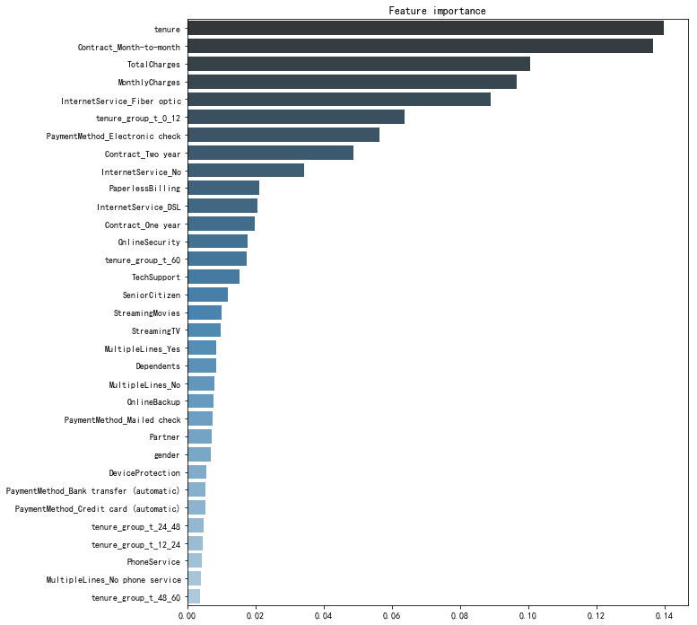

```python
from sklearn.ensemble import RandomForestClassifier

params = {'random_state': 0, 'n_jobs': 4, 'n_estimators': 5000, 'max_depth': 8}

X, y = data.drop(['Churn','customerID'],axis=1),data['Churn']
# Fit RandomForest Classifier
clf = RandomForestClassifier(**params)
clf = clf.fit(X,y)
# Plot features importances
imp = pd.Series(data=clf.feature_importances_,index=X.columns).sort_values(ascending=False)
plt.figure(figsize=(10,12))
plt.title("Feature importance")
ax = sns.barplot(y=imp.index,x=imp.values,palette="Blues_d",orient='h')
```

- 上面是通过随机森林算法计算出了所有特征在分类问题上的评分，而排位越靠前的特征对结果的影响力就越大
- 在后面构建预测模型的时候，上面的整个分析过程是有帮助的

这份数据中的流失和非流失的数据比例是不一致的，所以这是一个不平衡数据，对于不平衡数据是需要进行处理的，否则构建的预测模型会受到影响，导致预测不准确

```python
data['Churn'].value_counts()
```

```
0    5174
1    1869
Name: Churn, dtype: int64
```

```python
from sklearn.model_selection import train_test_split
from sklearn.linear_model import LogisticRegression
```

```python
from imblearn.over_sampling import SMOTE
from sklearn import metrics

cols = [col for col in data.columns if col not in Id_col + target_col]

smote_X = data[cols]
smote_y = data[target_col]

#分割数据
smote_train_X,smote_test_X,smote_train_y,smote_test_y = train_test_split(smote_X,smote_y,test_size=0.2,random_state=31)

s = SMOTE(random_state=0)
s_X,s_y = s.fit_sample(smote_train_X,smote_train_y)
s_X = pd.DataFrame(data=s_X,columns=cols)
s_y = pd.DataFrame(data=s_y,columns=target_col)
```

```python
#逻辑回归
lr = LogisticRegression()
lr.fit(s_X,s_y)

p_test = lr.predict(smote_test_X)
#预测准确率
print(metrics.accuracy_score(smote_test_y, p_test))
```

```
0.7572746628814763
```

```python
#随机森林
rfc = RandomForestClassifier(n_estimators=1000 , oob_score = True, n_jobs = -1,
                                  random_state =50, max_features = "auto",
                                  max_leaf_nodes = 30)
rfc.fit(s_X,s_y)
prediction_test = rfc.predict(smote_test_X)
#预测准确率
print (metrics.accuracy_score(smote_test_y, prediction_test))
```

```
0.772888573456352
```

```python
#XGBOOST模型
from xgboost import XGBClassifier
model = XGBClassifier()
model.fit(s_X,s_y)
preds = model.predict(smote_test_X)
#预测准确率
metrics.accuracy_score(smote_test_y,preds)
```

```
0.7877927608232789
```

```python
importances = model.feature_importances_
weights = pd.Series(importances,
                 index=smote_X.columns.values)
```

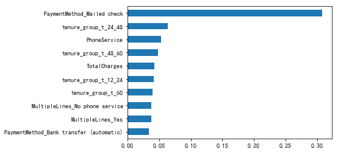

```python
weights.sort_values()[-10:].plot(kind = 'barh')
```

[figure not shown]

```python
weights.sort_values()[:10].plot(kind = 'barh')
```

总结：

- 老年人群体的流失要严重的多，需要针对老年人进行保留计划的制定
- 如果没有合伙人，那么流失的情况要更严重
- 如果没有家属，则客户流失的要更严重
- 从流失数据中可以看出使用Fiber optic服务后会更容易流失，所以需要针对这种类型的服务进行改进
- 保证提供给客户的一些附加服务，或者是售后服务（安全服务、备份服务、设备保护服务和技术支持服务）的质量可以降低客户流失
- 短期合约的客户流失较高
- 对于无纸服务的方式还需要进行改进
- 受到了电子发票这种方式的影响导致流失
- 新近的客户更容易流失
- 月费较高的人更容易流失